# Multi-Class Classification Model for Sensorless Drive Diagnosis Using Python Take 1

### September 13, 2019

Template Credit: Adapted from a template made available by Dr. Jason Brownlee of Machine Learning Mastery. [https://machinelearningmastery.com/]

SUMMARY: The purpose of this project is to construct a predictive model using various machine learning algorithms and to document the end-to-end steps using a template. The Sensorless Drive Diagnosis is a multi-class classification situation where we are trying to predict one of the several possible outcomes.

INTRODUCTION: The dataset contains features extracted from electric current drive signals. The drive has both intact and defective components. The signals can result in 11 different classes with different conditions. Each condition has been measured several times by 12 different operating conditions, such as speeds, load moments, and load forces.

In this iteration, we will establish the baseline accuracy measurement for comparison with future rounds of modeling.

ANALYSIS: The baseline performance of the machine learning algorithms achieved an average accuracy of 84.65%. Two algorithms (Random Forest and Extra Trees) achieved the top accuracy metrics after the first round of modeling. After a series of tuning trials, Extra Trees turned in the top overall result and achieved an accuracy metric of 99.95%. After applying the optimized parameters, the Extra Trees algorithm processed the testing dataset with an accuracy of 99.97%, which was even better than the prediction from the training data.

CONCLUSION: For this iteration, the Extra Trees algorithm achieved the best overall training and validation results. For this dataset, Extra Trees could be considered for further modeling.

Dataset Used: Sensorless Drive Diagnosis Data Set

Dataset ML Model: Multi-class classification with numerical attributes

Dataset Reference: https://archive.ics.uci.edu/ml/datasets/Dataset+for+Sensorless+Drive+Diagnosis

The project aims to touch on the following areas:

- Document a predictive modeling problem end-to-end.
- Explore data cleaning and transformation options
- Explore non-ensemble and ensemble algorithms for baseline model performance
- Explore algorithm tuning techniques for improving model performance

Any predictive modeling machine learning project genrally can be broken down into about six major tasks:

1. Prepare Environment
2. Summarize Data
3. Prepare Data
4. Model and Evaluate Algorithms
5. Improve Accuracy or Results
6. Finalize Model and Present Results

## Section 1 - Prepare Environment

### 1.a) Load libraries and modules

```python
# Set the warning message filter
import warnings
warnings.filterwarnings("ignore", category=FutureWarning)
warnings.filterwarnings("ignore", category=DeprecationWarning)
```

```python
import numpy as np
import pandas as pd
import matplotlib.pyplot as plt
import math
import os
import sys
import shutil
import urllib.request
import zipfile
import smtplib
import re
from datetime import datetime
from email.message import EmailMessage
from pandas.plotting import scatter_matrix
from sklearn import preprocessing
from sklearn.model_selection import train_test_split
from sklearn.model_selection import KFold
from sklearn.model_selection import StratifiedKFold
from sklearn.model_selection import cross_val_score
from sklearn.model_selection import GridSearchCV
from sklearn.metrics import classification_report
from sklearn.metrics import confusion_matrix
from sklearn.metrics import accuracy_score
from sklearn.metrics import roc_auc_score
from sklearn.pipeline import Pipeline
from sklearn.feature_selection import RFE
from imblearn.over_sampling import SMOTE
from imblearn.combine import SMOTEENN
from imblearn.combine import SMOTETomek

from sklearn.discriminant_analysis import LinearDiscriminantAnalysis
from sklearn.tree import DecisionTreeClassifier
from sklearn.neighbors import KNeighborsClassifier
from sklearn.ensemble import BaggingClassifier
from sklearn.ensemble import RandomForestClassifier
from sklearn.ensemble import ExtraTreesClassifier
from sklearn.ensemble import GradientBoostingClassifier
from imblearn.ensemble import BalancedRandomForestClassifier
from imblearn.ensemble import RUSBoostClassifier
from imblearn.ensemble import BalancedBaggingClassifier
from xgboost import XGBClassifier
```

### 1.b) Set up the controlling parameters and functions

```python
# Create the random seed number for reproducible results
seedNum = 888

# Set up the number of CPU cores available for multi-thread processing
cpu_num = 6

# Set up the flag to stop sending progress emails (setting to True will send status emails!)
notifyStatus = False
```

```python
# Run algorithms using 10-fold cross validation
num_folds = 10
scoring = 'accuracy'
```

```python
# Set up the email notification function
def email_notify(msg_text):
    sender = os.environ.get('MAIL_SENDER')
    receiver = os.environ.get('MAIL_RECEIVER')
    gateway = os.environ.get('SMTP_GATEWAY')
    smtpuser = os.environ.get('SMTP_USERNAME')
    password = os.environ.get('SMTP_PASSWORD')
    if sender==None or receiver==None or gateway==None or smtpuser==None or password==None:
        sys.exit("Incomplete email setup info. Script Processing Aborted!!!")
    msg = EmailMessage()
    msg.set_content(msg_text)
    msg['Subject'] = 'Notification from Python Multi-Class Classification Script'
    msg['From'] = sender
    msg['To'] = receiver
    server = smtplib.SMTP(gateway, 587)
    server.starttls()
    server.login(smtpuser, password)
    server.send_message(msg)
    server.quit()
```

```python
if (notifyStatus): email_notify("Library and Data Loading has begun! "+datetime.now().strftime('%a %B %d, %Y %I:%M:%S %p'))
```

### 1.c) Load dataset

```python
startTimeScript = datetime.now()

dataset_path = 'https://archive.ics.uci.edu/ml/machine-learning-databases/00325/Sensorless_drive_diagnosis.txt'
dest_file = os.path.basename(dataset_path)
if (os.path.isfile(dest_file) == False) :
    print('Downloading ' + dataset_path + ' as ' + dest_file)
    with urllib.request.urlopen(dataset_path) as in_resp, open(dest_file, 'wb') as out_file:
        shutil.copyfileobj(in_resp, out_file)
    print(dest_file + 'downloaded!')
#     print('Unpacking ' + dest_file)
#     with zipfile.ZipFile(dest_file, 'r') as zip_ref:
#         zip_ref.extractall('.')
#     print(dest_file + 'unpacked!')

inputFile = dest_file
colNames = ["attr" + str(i) for i in range(1,49)]
colNames.append("targetVar")
Xy_original = pd.read_csv(inputFile, names=colNames, sep=' ')
```

```python
# Take a peek at the dataframe after the import
Xy_original.head(10)
```

|  | attr1 | attr2 | attr3 | attr4 | attr5 | attr6 | attr7 | attr8 | attr9 | attr10 | ... | attr40 | attr41 | attr42 | attr43 | attr44 | attr45 | attr46 | attr47 | attr48 | targetVar |
| --- | --- | --- | --- | --- | --- | --- | --- | --- | --- | --- | --- | --- | --- | --- | --- | --- | --- | --- | --- | --- | --- |
| 0 | -3.014600e-07 | 8.260300e-06 | -0.000012 | -2.309800e-06 | -1.438600e-06 | -0.000021 | 0.031718 | 0.031710 | 0.031721 | -0.032963 | ... | -0.63308 | 2.9646 | 8.1198 | -1.4961 | -1.4961 | -1.4961 | -1.4996 | -1.4996 | -1.4996 | 1 |
| 1 | 2.913200e-06 | -5.247700e-06 | 0.000003 | -6.056100e-06 | 2.778900e-06 | -0.000004 | 0.030804 | 0.030810 | 0.030806 | -0.033520 | ... | -0.59314 | 7.6252 | 6.1690 | -1.4967 | -1.4967 | -1.4967 | -1.5005 | -1.5005 | -1.5005 | 1 |
| 2 | -2.951700e-06 | -3.184000e-06 | -0.000016 | -1.208400e-06 | -1.575300e-06 | 0.000017 | 0.032877 | 0.032880 | 0.032896 | -0.029834 | ... | -0.63252 | 2.7784 | 5.3017 | -1.4983 | -1.4983 | -1.4982 | -1.4985 | -1.4985 | -1.4985 | 1 |
| 3 | -1.322600e-06 | 8.820100e-06 | -0.000016 | -4.811100e-06 | -7.282900e-07 | 0.000004 | 0.029410 | 0.029401 | 0.029417 | -0.030156 | ... | -0.62289 | 6.5534 | 6.2606 | -1.4963 | -1.4963 | -1.4963 | -1.4975 | -1.4975 | -1.4976 | 1 |
| 4 | -6.836600e-08 | 5.666300e-07 | -0.000026 | -6.490100e-06 | -7.940600e-07 | 0.000013 | 0.030119 | 0.030119 | 0.030145 | -0.031393 | ... | -0.63010 | 4.5155 | 9.5231 | -1.4958 | -1.4958 | -1.4958 | -1.4959 | -1.4959 | -1.4959 | 1 |
| 5 | -9.584900e-07 | 5.214300e-08 | -0.000047 | 6.453700e-07 | -2.304100e-06 | 0.000055 | 0.031154 | 0.031154 | 0.031201 | -0.032789 | ... | -0.61124 | 5.8337 | 18.6970 | -1.4956 | -1.4956 | -1.4956 | -1.4973 | -1.4972 | -1.4973 | 1 |
| 6 | -1.783700e-06 | 1.303600e-06 | -0.000038 | -7.083900e-06 | 6.706300e-06 | 0.000022 | 0.033805 | 0.033804 | 0.033841 | -0.033345 | ... | -0.62501 | 17.6180 | 9.0823 | -1.4960 | -1.4960 | -1.4959 | -1.4954 | -1.4954 | -1.4953 | 1 |
| 7 | -2.566600e-06 | -1.679500e-07 | 0.000015 | -1.598400e-06 | 8.709200e-07 | 0.000015 | 0.031071 | 0.031071 | 0.031056 | -0.029695 | ... | -0.63618 | 12.8380 | 4.9079 | -1.4990 | -1.4990 | -1.4990 | -1.4968 | -1.4968 | -1.4968 | 1 |
| 8 | -5.474000e-06 | 1.086500e-07 | -0.000011 | -1.815600e-06 | 4.757800e-07 | 0.000024 | 0.031309 | 0.031308 | 0.031319 | -0.031344 | ... | -0.62465 | 2.9841 | 6.6883 | -1.4955 | -1.4955 | -1.4955 | -1.4947 | -1.4947 | -1.4947 | 1 |
| 9 | 2.825600e-06 | 6.067600e-06 | 0.000118 | -4.347500e-06 | 1.492300e-06 | -0.000003 | 0.030947 | 0.030941 | 0.030823 | -0.032171 | ... | -0.58170 | 2.0511 | 8.8939 | -1.4963 | -1.4963 | -1.4963 | -1.4943 | -1.4943 | -1.4943 | 1 |

10 rows × 49 columns

```python
Xy_original.info()
```

```
<class 'pandas.core.frame.DataFrame'>
RangeIndex: 58509 entries, 0 to 58508
Data columns (total 49 columns):
attr1        58509 non-null float64
attr2        58509 non-null float64
attr3        58509 non-null float64
attr4        58509 non-null float64
attr5        58509 non-null float64
attr6        58509 non-null float64
attr7        58509 non-null float64
attr8        58509 non-null float64
attr9        58509 non-null float64
attr10       58509 non-null float64
attr11       58509 non-null float64
attr12       58509 non-null float64
attr13       58509 non-null float64
attr14       58509 non-null float64
attr15       58509 non-null float64
attr16       58509 non-null float64
attr17       58509 non-null float64
attr18       58509 non-null float64
attr19       58509 non-null float64
attr20       58509 non-null float64
attr21       58509 non-null float64
attr22       58509 non-null float64
attr23       58509 non-null float64
attr24       58509 non-null float64
attr25       58509 non-null float64
attr26       58509 non-null float64
attr27       58509 non-null float64
attr28       58509 non-null float64
attr29       58509 non-null float64
attr30       58509 non-null float64
attr31       58509 non-null float64
attr32       58509 non-null float64
attr33       58509 non-null float64
attr34       58509 non-null float64
attr35       58509 non-null float64
attr36       58509 non-null float64
attr37       58509 non-null float64
attr38       58509 non-null float64
attr39       58509 non-null float64
attr40       58509 non-null float64
attr41       58509 non-null float64
attr42       58509 non-null float64
attr43       58509 non-null float64
attr44       58509 non-null float64
attr45       58509 non-null float64
attr46       58509 non-null float64
attr47       58509 non-null float64
attr48       58509 non-null float64
targetVar    58509 non-null int64
dtypes: float64(48), int64(1)
memory usage: 21.9 MB
```

```python
Xy_original.describe()
```

|  | attr1 | attr2 | attr3 | attr4 | attr5 | attr6 | attr7 | attr8 | attr9 | attr10 | ... | attr40 | attr41 | attr42 | attr43 | attr44 | attr45 | attr46 | attr47 | attr48 | targetVar |
| --- | --- | --- | --- | --- | --- | --- | --- | --- | --- | --- | --- | --- | --- | --- | --- | --- | --- | --- | --- | --- | --- |
| count | 58509.000000 | 5.850900e+04 | 5.850900e+04 | 58509.000000 | 5.850900e+04 | 5.850900e+04 | 58509.000000 | 58509.000000 | 58509.000000 | 58509.000000 | ... | 58509.000000 | 58509.000000 | 58509.000000 | 58509.000000 | 58509.000000 | 58509.000000 | 58509.000000 | 58509.000000 | 58509.000000 | 58509.000000 |
| mean | -0.000003 | 1.439648e-06 | 1.412013e-06 | -0.000001 | 1.351239e-06 | -2.654483e-07 | 0.001915 | 0.001913 | 0.001912 | -0.011897 | ... | -0.397757 | 7.293781 | 8.273772 | -1.500887 | -1.500912 | -1.500805 | -1.497771 | -1.497794 | -1.497686 | 6.000000 |
| std | 0.000072 | 5.555429e-05 | 2.353009e-04 | 0.000063 | 5.660943e-05 | 2.261907e-04 | 0.036468 | 0.036465 | 0.036470 | 0.066482 | ... | 25.018728 | 12.451781 | 6.565952 | 0.003657 | 0.003668 | 0.003632 | 0.003163 | 0.003163 | 0.003175 | 3.162305 |
| min | -0.013721 | -5.414400e-03 | -1.358000e-02 | -0.012787 | -8.355900e-03 | -9.741300e-03 | -0.139890 | -0.135940 | -0.130860 | -0.218640 | ... | -0.902350 | -0.596830 | 0.320660 | -1.525500 | -1.526200 | -1.523700 | -1.521400 | -1.523200 | -1.521300 | 1.000000 |
| 25% | -0.000007 | -1.444400e-05 | -7.239600e-05 | -0.000005 | -1.475300e-05 | -7.379100e-05 | -0.019927 | -0.019951 | -0.019925 | -0.032144 | ... | -0.715470 | 1.450300 | 4.436300 | -1.503300 | -1.503400 | -1.503200 | -1.499600 | -1.499600 | -1.499500 | 3.000000 |
| 50% | -0.000003 | 8.804600e-07 | 5.137700e-07 | -0.000001 | 7.540200e-07 | -1.659300e-07 | 0.013226 | 0.013230 | 0.013247 | -0.015566 | ... | -0.661710 | 3.301300 | 6.479100 | -1.500300 | -1.500300 | -1.500300 | -1.498100 | -1.498100 | -1.498000 | 6.000000 |
| 75% | 0.000002 | 1.877700e-05 | 7.520000e-05 | 0.000004 | 1.906200e-05 | 7.138600e-05 | 0.024770 | 0.024776 | 0.024777 | 0.020614 | ... | -0.573980 | 8.288500 | 9.857500 | -1.498200 | -1.498200 | -1.498200 | -1.496200 | -1.496300 | -1.496200 | 9.000000 |
| max | 0.005784 | 4.525300e-03 | 5.237700e-03 | 0.001453 | 8.245100e-04 | 2.753600e-03 | 0.069125 | 0.069130 | 0.069131 | 0.352580 | ... | 3670.800000 | 889.930000 | 153.150000 | -1.457600 | -1.456100 | -1.455500 | -1.337200 | -1.337200 | -1.337100 | 11.000000 |

8 rows × 49 columns

```python
print(Xy_original.isnull().sum())
print('Total number of NaN in the dataframe: ', Xy_original.isnull().sum().sum())
```

```
attr1        0
attr2        0
attr3        0
attr4        0
attr5        0
attr6        0
attr7        0
attr8        0
attr9        0
attr10       0
attr11       0
attr12       0
attr13       0
attr14       0
attr15       0
attr16       0
attr17       0
attr18       0
attr19       0
attr20       0
attr21       0
attr22       0
attr23       0
attr24       0
attr25       0
attr26       0
attr27       0
attr28       0
attr29       0
attr30       0
attr31       0
attr32       0
attr33       0
attr34       0
attr35       0
attr36       0
attr37       0
attr38       0
attr39       0
attr40       0
attr41       0
attr42       0
attr43       0
attr44       0
attr45       0
attr46       0
attr47       0
attr48       0
targetVar    0
dtype: int64
Total number of NaN in the dataframe:  0
```

### 1.d) Data Cleaning

```python
# Standardize the class column to the name of targetVar if required
# Xy_original = Xy_original.rename(columns={'old_name': 'targetVar'})

# Dropping features
# Xy_original.drop(columns=['column1','column2','column3'], inplace=True)

# Impute missing values
# Xy_original['col_name'].fillna('someValue', inplace=True)
# Xy_original['col_name'].fillna(value=Xy_original['col_name'].median(), inplace=True)

# Convert columns from one data type to another
# Xy_original.column_name = Xy_original.column_name.astype('int')
# Xy_original.column_name = Xy_original.column_name.astype('category')

# Convert features with 1/0 levels into categorical feature of Y/N
# def reClassSomecol(code):
#     if (code == 1): return 'Y'
#     else: return 'N'
# Xy_original['targetVar] = Xy_original['targetVar'].apply(reClassSomecol)
```

```python
# Take a peek at the dataframe after the cleaning
Xy_original.head(10)
```

|  | attr1 | attr2 | attr3 | attr4 | attr5 | attr6 | attr7 | attr8 | attr9 | attr10 | ... | attr40 | attr41 | attr42 | attr43 | attr44 | attr45 | attr46 | attr47 | attr48 | targetVar |
| --- | --- | --- | --- | --- | --- | --- | --- | --- | --- | --- | --- | --- | --- | --- | --- | --- | --- | --- | --- | --- | --- |
| 0 | -3.014600e-07 | 8.260300e-06 | -0.000012 | -2.309800e-06 | -1.438600e-06 | -0.000021 | 0.031718 | 0.031710 | 0.031721 | -0.032963 | ... | -0.63308 | 2.9646 | 8.1198 | -1.4961 | -1.4961 | -1.4961 | -1.4996 | -1.4996 | -1.4996 | 1 |
| 1 | 2.913200e-06 | -5.247700e-06 | 0.000003 | -6.056100e-06 | 2.778900e-06 | -0.000004 | 0.030804 | 0.030810 | 0.030806 | -0.033520 | ... | -0.59314 | 7.6252 | 6.1690 | -1.4967 | -1.4967 | -1.4967 | -1.5005 | -1.5005 | -1.5005 | 1 |
| 2 | -2.951700e-06 | -3.184000e-06 | -0.000016 | -1.208400e-06 | -1.575300e-06 | 0.000017 | 0.032877 | 0.032880 | 0.032896 | -0.029834 | ... | -0.63252 | 2.7784 | 5.3017 | -1.4983 | -1.4983 | -1.4982 | -1.4985 | -1.4985 | -1.4985 | 1 |
| 3 | -1.322600e-06 | 8.820100e-06 | -0.000016 | -4.811100e-06 | -7.282900e-07 | 0.000004 | 0.029410 | 0.029401 | 0.029417 | -0.030156 | ... | -0.62289 | 6.5534 | 6.2606 | -1.4963 | -1.4963 | -1.4963 | -1.4975 | -1.4975 | -1.4976 | 1 |
| 4 | -6.836600e-08 | 5.666300e-07 | -0.000026 | -6.490100e-06 | -7.940600e-07 | 0.000013 | 0.030119 | 0.030119 | 0.030145 | -0.031393 | ... | -0.63010 | 4.5155 | 9.5231 | -1.4958 | -1.4958 | -1.4958 | -1.4959 | -1.4959 | -1.4959 | 1 |
| 5 | -9.584900e-07 | 5.214300e-08 | -0.000047 | 6.453700e-07 | -2.304100e-06 | 0.000055 | 0.031154 | 0.031154 | 0.031201 | -0.032789 | ... | -0.61124 | 5.8337 | 18.6970 | -1.4956 | -1.4956 | -1.4956 | -1.4973 | -1.4972 | -1.4973 | 1 |
| 6 | -1.783700e-06 | 1.303600e-06 | -0.000038 | -7.083900e-06 | 6.706300e-06 | 0.000022 | 0.033805 | 0.033804 | 0.033841 | -0.033345 | ... | -0.62501 | 17.6180 | 9.0823 | -1.4960 | -1.4960 | -1.4959 | -1.4954 | -1.4954 | -1.4953 | 1 |
| 7 | -2.566600e-06 | -1.679500e-07 | 0.000015 | -1.598400e-06 | 8.709200e-07 | 0.000015 | 0.031071 | 0.031071 | 0.031056 | -0.029695 | ... | -0.63618 | 12.8380 | 4.9079 | -1.4990 | -1.4990 | -1.4990 | -1.4968 | -1.4968 | -1.4968 | 1 |
| 8 | -5.474000e-06 | 1.086500e-07 | -0.000011 | -1.815600e-06 | 4.757800e-07 | 0.000024 | 0.031309 | 0.031308 | 0.031319 | -0.031344 | ... | -0.62465 | 2.9841 | 6.6883 | -1.4955 | -1.4955 | -1.4955 | -1.4947 | -1.4947 | -1.4947 | 1 |
| 9 | 2.825600e-06 | 6.067600e-06 | 0.000118 | -4.347500e-06 | 1.492300e-06 | -0.000003 | 0.030947 | 0.030941 | 0.030823 | -0.032171 | ... | -0.58170 | 2.0511 | 8.8939 | -1.4963 | -1.4963 | -1.4963 | -1.4943 | -1.4943 | -1.4943 | 1 |

10 rows × 49 columns

```python
Xy_original.info()
```

```
<class 'pandas.core.frame.DataFrame'>
RangeIndex: 58509 entries, 0 to 58508
Data columns (total 49 columns):
attr1        58509 non-null float64
attr2        58509 non-null float64
attr3        58509 non-null float64
attr4        58509 non-null float64
attr5        58509 non-null float64
attr6        58509 non-null float64
attr7        58509 non-null float64
attr8        58509 non-null float64
attr9        58509 non-null float64
attr10       58509 non-null float64
attr11       58509 non-null float64
attr12       58509 non-null float64
attr13       58509 non-null float64
attr14       58509 non-null float64
attr15       58509 non-null float64
attr16       58509 non-null float64
attr17       58509 non-null float64
attr18       58509 non-null float64
attr19       58509 non-null float64
attr20       58509 non-null float64
attr21       58509 non-null float64
attr22       58509 non-null float64
attr23       58509 non-null float64
attr24       58509 non-null float64
attr25       58509 non-null float64
attr26       58509 non-null float64
attr27       58509 non-null float64
attr28       58509 non-null float64
attr29       58509 non-null float64
attr30       58509 non-null float64
attr31       58509 non-null float64
attr32       58509 non-null float64
attr33       58509 non-null float64
attr34       58509 non-null float64
attr35       58509 non-null float64
attr36       58509 non-null float64
attr37       58509 non-null float64
attr38       58509 non-null float64
attr39       58509 non-null float64
attr40       58509 non-null float64
attr41       58509 non-null float64
attr42       58509 non-null float64
attr43       58509 non-null float64
attr44       58509 non-null float64
attr45       58509 non-null float64
attr46       58509 non-null float64
attr47       58509 non-null float64
attr48       58509 non-null float64
targetVar    58509 non-null int64
dtypes: float64(48), int64(1)
memory usage: 21.9 MB
```

```python
Xy_original.describe()
```

|  | attr1 | attr2 | attr3 | attr4 | attr5 | attr6 | attr7 | attr8 | attr9 | attr10 | ... | attr40 | attr41 | attr42 | attr43 | attr44 | attr45 | attr46 | attr47 | attr48 | targetVar |
| --- | --- | --- | --- | --- | --- | --- | --- | --- | --- | --- | --- | --- | --- | --- | --- | --- | --- | --- | --- | --- | --- |
| count | 58509.000000 | 5.850900e+04 | 5.850900e+04 | 58509.000000 | 5.850900e+04 | 5.850900e+04 | 58509.000000 | 58509.000000 | 58509.000000 | 58509.000000 | ... | 58509.000000 | 58509.000000 | 58509.000000 | 58509.000000 | 58509.000000 | 58509.000000 | 58509.000000 | 58509.000000 | 58509.000000 | 58509.000000 |
| mean | -0.000003 | 1.439648e-06 | 1.412013e-06 | -0.000001 | 1.351239e-06 | -2.654483e-07 | 0.001915 | 0.001913 | 0.001912 | -0.011897 | ... | -0.397757 | 7.293781 | 8.273772 | -1.500887 | -1.500912 | -1.500805 | -1.497771 | -1.497794 | -1.497686 | 6.000000 |
| std | 0.000072 | 5.555429e-05 | 2.353009e-04 | 0.000063 | 5.660943e-05 | 2.261907e-04 | 0.036468 | 0.036465 | 0.036470 | 0.066482 | ... | 25.018728 | 12.451781 | 6.565952 | 0.003657 | 0.003668 | 0.003632 | 0.003163 | 0.003163 | 0.003175 | 3.162305 |
| min | -0.013721 | -5.414400e-03 | -1.358000e-02 | -0.012787 | -8.355900e-03 | -9.741300e-03 | -0.139890 | -0.135940 | -0.130860 | -0.218640 | ... | -0.902350 | -0.596830 | 0.320660 | -1.525500 | -1.526200 | -1.523700 | -1.521400 | -1.523200 | -1.521300 | 1.000000 |
| 25% | -0.000007 | -1.444400e-05 | -7.239600e-05 | -0.000005 | -1.475300e-05 | -7.379100e-05 | -0.019927 | -0.019951 | -0.019925 | -0.032144 | ... | -0.715470 | 1.450300 | 4.436300 | -1.503300 | -1.503400 | -1.503200 | -1.499600 | -1.499600 | -1.499500 | 3.000000 |
| 50% | -0.000003 | 8.804600e-07 | 5.137700e-07 | -0.000001 | 7.540200e-07 | -1.659300e-07 | 0.013226 | 0.013230 | 0.013247 | -0.015566 | ... | -0.661710 | 3.301300 | 6.479100 | -1.500300 | -1.500300 | -1.500300 | -1.498100 | -1.498100 | -1.498000 | 6.000000 |
| 75% | 0.000002 | 1.877700e-05 | 7.520000e-05 | 0.000004 | 1.906200e-05 | 7.138600e-05 | 0.024770 | 0.024776 | 0.024777 | 0.020614 | ... | -0.573980 | 8.288500 | 9.857500 | -1.498200 | -1.498200 | -1.498200 | -1.496200 | -1.496300 | -1.496200 | 9.000000 |
| max | 0.005784 | 4.525300e-03 | 5.237700e-03 | 0.001453 | 8.245100e-04 | 2.753600e-03 | 0.069125 | 0.069130 | 0.069131 | 0.352580 | ... | 3670.800000 | 889.930000 | 153.150000 | -1.457600 | -1.456100 | -1.455500 | -1.337200 | -1.337200 | -1.337100 | 11.000000 |

8 rows × 49 columns

```python
print(Xy_original.isnull().sum())
print('Total number of NaN in the dataframe: ', Xy_original.isnull().sum().sum())
```

```
attr1        0
attr2        0
attr3        0
attr4        0
attr5        0
attr6        0
attr7        0
attr8        0
attr9        0
attr10       0
attr11       0
attr12       0
attr13       0
attr14       0
attr15       0
attr16       0
attr17       0
attr18       0
attr19       0
attr20       0
attr21       0
attr22       0
attr23       0
attr24       0
attr25       0
attr26       0
attr27       0
attr28       0
attr29       0
attr30       0
attr31       0
attr32       0
attr33       0
attr34       0
attr35       0
attr36       0
attr37       0
attr38       0
attr39       0
attr40       0
attr41       0
attr42       0
attr43       0
attr44       0
attr45       0
attr46       0
attr47       0
attr48       0
targetVar    0
dtype: int64
Total number of NaN in the dataframe:  0
```

### 1.e) Splitting Data into Attribute-only and Target-only Sets

```python
# Use variable totCol to hold the number of columns in the dataframe
totCol = len(Xy_original.columns)

# Set up variable totAttr for the total number of attribute columns
totAttr = totCol-1

# targetCol variable indicates the column location of the target/class variable
# If the first column, set targetCol to 1. If the last column, set targetCol to totCol
# If (targetCol <> 1) and (targetCol <> totCol), be aware when slicing up the dataframes for visualization
targetCol = totCol
```

```python
# We create attribute-only and target-only datasets (X_original and y_original)
# for various visualization and cleaning/transformation operations

if targetCol == totCol:
    X_original = Xy_original.iloc[:,0:totAttr]
    y_original = Xy_original.iloc[:,totAttr]
else:
    X_original = Xy_original.iloc[:,1:totCol]
    y_original = Xy_original.iloc[:,0]

print("Xy_original.shape: {} X_original.shape: {} y_original.shape: {}".format(Xy_original.shape, X_original.shape, y_original.shape))
```

```
Xy_original.shape: (58509, 49) X_original.shape: (58509, 48) y_original.shape: (58509,)
```

### 1.f) Set up the parameters for data visualization

```python
# Set up the number of row and columns for visualization display. dispRow * dispCol should be >= totAttr
dispCol = 4
if totAttr % dispCol == 0 :
    dispRow = totAttr // dispCol
else :
    dispRow = (totAttr // dispCol) + 1

# Set figure width to display the data visualization plots
fig_size = plt.rcParams["figure.figsize"]
fig_size[0] = dispCol*4
fig_size[1] = dispRow*4
plt.rcParams["figure.figsize"] = fig_size
```

```python
if (notifyStatus): email_notify("Library and Data Loading completed! "+datetime.now().strftime('%a %B %d, %Y %I:%M:%S %p'))
```

## Section 2 - Summarize Data

To gain a better understanding of the data that we have on-hand, we will leverage a number of descriptive statistics and data visualization techniques. The plan is to use the results to consider new questions, review assumptions, and validate hypotheses that we can investigate later with specialized models.

```python
if (notifyStatus): email_notify("Data Summarization and Visualization has begun! "+datetime.now().strftime('%a %B %d, %Y %I:%M:%S %p'))
```

### 2.a) Descriptive Statistics

#### 2.a.i) Peek at the attribute columns

```python
X_original.head(10)
```

|  | attr1 | attr2 | attr3 | attr4 | attr5 | attr6 | attr7 | attr8 | attr9 | attr10 | ... | attr39 | attr40 | attr41 | attr42 | attr43 | attr44 | attr45 | attr46 | attr47 | attr48 |
| --- | --- | --- | --- | --- | --- | --- | --- | --- | --- | --- | --- | --- | --- | --- | --- | --- | --- | --- | --- | --- | --- |
| 0 | -3.014600e-07 | 8.260300e-06 | -0.000012 | -2.309800e-06 | -1.438600e-06 | -0.000021 | 0.031718 | 0.031710 | 0.031721 | -0.032963 | ... | 6.0168 | -0.63308 | 2.9646 | 8.1198 | -1.4961 | -1.4961 | -1.4961 | -1.4996 | -1.4996 | -1.4996 |
| 1 | 2.913200e-06 | -5.247700e-06 | 0.000003 | -6.056100e-06 | 2.778900e-06 | -0.000004 | 0.030804 | 0.030810 | 0.030806 | -0.033520 | ... | 3.6048 | -0.59314 | 7.6252 | 6.1690 | -1.4967 | -1.4967 | -1.4967 | -1.5005 | -1.5005 | -1.5005 |
| 2 | -2.951700e-06 | -3.184000e-06 | -0.000016 | -1.208400e-06 | -1.575300e-06 | 0.000017 | 0.032877 | 0.032880 | 0.032896 | -0.029834 | ... | 5.8007 | -0.63252 | 2.7784 | 5.3017 | -1.4983 | -1.4983 | -1.4982 | -1.4985 | -1.4985 | -1.4985 |
| 3 | -1.322600e-06 | 8.820100e-06 | -0.000016 | -4.811100e-06 | -7.282900e-07 | 0.000004 | 0.029410 | 0.029401 | 0.029417 | -0.030156 | ... | 23.3960 | -0.62289 | 6.5534 | 6.2606 | -1.4963 | -1.4963 | -1.4963 | -1.4975 | -1.4975 | -1.4976 |
| 4 | -6.836600e-08 | 5.666300e-07 | -0.000026 | -6.490100e-06 | -7.940600e-07 | 0.000013 | 0.030119 | 0.030119 | 0.030145 | -0.031393 | ... | 5.0582 | -0.63010 | 4.5155 | 9.5231 | -1.4958 | -1.4958 | -1.4958 | -1.4959 | -1.4959 | -1.4959 |
| 5 | -9.584900e-07 | 5.214300e-08 | -0.000047 | 6.453700e-07 | -2.304100e-06 | 0.000055 | 0.031154 | 0.031154 | 0.031201 | -0.032789 | ... | 3.9757 | -0.61124 | 5.8337 | 18.6970 | -1.4956 | -1.4956 | -1.4956 | -1.4973 | -1.4972 | -1.4973 |
| 6 | -1.783700e-06 | 1.303600e-06 | -0.000038 | -7.083900e-06 | 6.706300e-06 | 0.000022 | 0.033805 | 0.033804 | 0.033841 | -0.033345 | ... | 2.7104 | -0.62501 | 17.6180 | 9.0823 | -1.4960 | -1.4960 | -1.4959 | -1.4954 | -1.4954 | -1.4953 |
| 7 | -2.566600e-06 | -1.679500e-07 | 0.000015 | -1.598400e-06 | 8.709200e-07 | 0.000015 | 0.031071 | 0.031071 | 0.031056 | -0.029695 | ... | 9.8584 | -0.63618 | 12.8380 | 4.9079 | -1.4990 | -1.4990 | -1.4990 | -1.4968 | -1.4968 | -1.4968 |
| 8 | -5.474000e-06 | 1.086500e-07 | -0.000011 | -1.815600e-06 | 4.757800e-07 | 0.000024 | 0.031309 | 0.031308 | 0.031319 | -0.031344 | ... | 3.0311 | -0.62465 | 2.9841 | 6.6883 | -1.4955 | -1.4955 | -1.4955 | -1.4947 | -1.4947 | -1.4947 |
| 9 | 2.825600e-06 | 6.067600e-06 | 0.000118 | -4.347500e-06 | 1.492300e-06 | -0.000003 | 0.030947 | 0.030941 | 0.030823 | -0.032171 | ... | 25.5770 | -0.58170 | 2.0511 | 8.8939 | -1.4963 | -1.4963 | -1.4963 | -1.4943 | -1.4943 | -1.4943 |

10 rows × 48 columns

#### 2.a.ii) Dimensions and attribute types

```python
X_original.info()
```

```
<class 'pandas.core.frame.DataFrame'>
RangeIndex: 58509 entries, 0 to 58508
Data columns (total 48 columns):
attr1     58509 non-null float64
attr2     58509 non-null float64
attr3     58509 non-null float64
attr4     58509 non-null float64
attr5     58509 non-null float64
attr6     58509 non-null float64
attr7     58509 non-null float64
attr8     58509 non-null float64
attr9     58509 non-null float64
attr10    58509 non-null float64
attr11    58509 non-null float64
attr12    58509 non-null float64
attr13    58509 non-null float64
attr14    58509 non-null float64
attr15    58509 non-null float64
attr16    58509 non-null float64
attr17    58509 non-null float64
attr18    58509 non-null float64
attr19    58509 non-null float64
attr20    58509 non-null float64
attr21    58509 non-null float64
attr22    58509 non-null float64
attr23    58509 non-null float64
attr24    58509 non-null float64
attr25    58509 non-null float64
attr26    58509 non-null float64
attr27    58509 non-null float64
attr28    58509 non-null float64
attr29    58509 non-null float64
attr30    58509 non-null float64
attr31    58509 non-null float64
attr32    58509 non-null float64
attr33    58509 non-null float64
attr34    58509 non-null float64
attr35    58509 non-null float64
attr36    58509 non-null float64
attr37    58509 non-null float64
attr38    58509 non-null float64
attr39    58509 non-null float64
attr40    58509 non-null float64
attr41    58509 non-null float64
attr42    58509 non-null float64
attr43    58509 non-null float64
attr44    58509 non-null float64
attr45    58509 non-null float64
attr46    58509 non-null float64
attr47    58509 non-null float64
attr48    58509 non-null float64
dtypes: float64(48)
memory usage: 21.4 MB
```

#### 2.a.iii) Statistical summary of the attributes

```python
X_original.describe()
```

|  | attr1 | attr2 | attr3 | attr4 | attr5 | attr6 | attr7 | attr8 | attr9 | attr10 | ... | attr39 | attr40 | attr41 | attr42 | attr43 | attr44 | attr45 | attr46 | attr47 | attr48 |
| --- | --- | --- | --- | --- | --- | --- | --- | --- | --- | --- | --- | --- | --- | --- | --- | --- | --- | --- | --- | --- | --- |
| count | 58509.000000 | 5.850900e+04 | 5.850900e+04 | 58509.000000 | 5.850900e+04 | 5.850900e+04 | 58509.000000 | 58509.000000 | 58509.000000 | 58509.000000 | ... | 58509.000000 | 58509.000000 | 58509.000000 | 58509.000000 | 58509.000000 | 58509.000000 | 58509.000000 | 58509.000000 | 58509.000000 | 58509.000000 |
| mean | -0.000003 | 1.439648e-06 | 1.412013e-06 | -0.000001 | 1.351239e-06 | -2.654483e-07 | 0.001915 | 0.001913 | 0.001912 | -0.011897 | ... | 8.406765 | -0.397757 | 7.293781 | 8.273772 | -1.500887 | -1.500912 | -1.500805 | -1.497771 | -1.497794 | -1.497686 |
| std | 0.000072 | 5.555429e-05 | 2.353009e-04 | 0.000063 | 5.660943e-05 | 2.261907e-04 | 0.036468 | 0.036465 | 0.036470 | 0.066482 | ... | 6.897301 | 25.018728 | 12.451781 | 6.565952 | 0.003657 | 0.003668 | 0.003632 | 0.003163 | 0.003163 | 0.003175 |
| min | -0.013721 | -5.414400e-03 | -1.358000e-02 | -0.012787 | -8.355900e-03 | -9.741300e-03 | -0.139890 | -0.135940 | -0.130860 | -0.218640 | ... | 0.522180 | -0.902350 | -0.596830 | 0.320660 | -1.525500 | -1.526200 | -1.523700 | -1.521400 | -1.523200 | -1.521300 |
| 25% | -0.000007 | -1.444400e-05 | -7.239600e-05 | -0.000005 | -1.475300e-05 | -7.379100e-05 | -0.019927 | -0.019951 | -0.019925 | -0.032144 | ... | 4.451300 | -0.715470 | 1.450300 | 4.436300 | -1.503300 | -1.503400 | -1.503200 | -1.499600 | -1.499600 | -1.499500 |
| 50% | -0.000003 | 8.804600e-07 | 5.137700e-07 | -0.000001 | 7.540200e-07 | -1.659300e-07 | 0.013226 | 0.013230 | 0.013247 | -0.015566 | ... | 6.566800 | -0.661710 | 3.301300 | 6.479100 | -1.500300 | -1.500300 | -1.500300 | -1.498100 | -1.498100 | -1.498000 |
| 75% | 0.000002 | 1.877700e-05 | 7.520000e-05 | 0.000004 | 1.906200e-05 | 7.138600e-05 | 0.024770 | 0.024776 | 0.024777 | 0.020614 | ... | 9.952600 | -0.573980 | 8.288500 | 9.857500 | -1.498200 | -1.498200 | -1.498200 | -1.496200 | -1.496300 | -1.496200 |
| max | 0.005784 | 4.525300e-03 | 5.237700e-03 | 0.001453 | 8.245100e-04 | 2.753600e-03 | 0.069125 | 0.069130 | 0.069131 | 0.352580 | ... | 265.330000 | 3670.800000 | 889.930000 | 153.150000 | -1.457600 | -1.456100 | -1.455500 | -1.337200 | -1.337200 | -1.337100 |

8 rows × 48 columns

#### 2.a.iv) Summarize the levels of the class attribute

```python
Xy_original.groupby('targetVar').size()
```

```
targetVar
1     5319
2     5319
3     5319
4     5319
5     5319
6     5319
7     5319
8     5319
9     5319
10    5319
11    5319
dtype: int64
```

### 2.b) Data Visualization

##### 2.b.i) Univariate plots to better understand each attribute

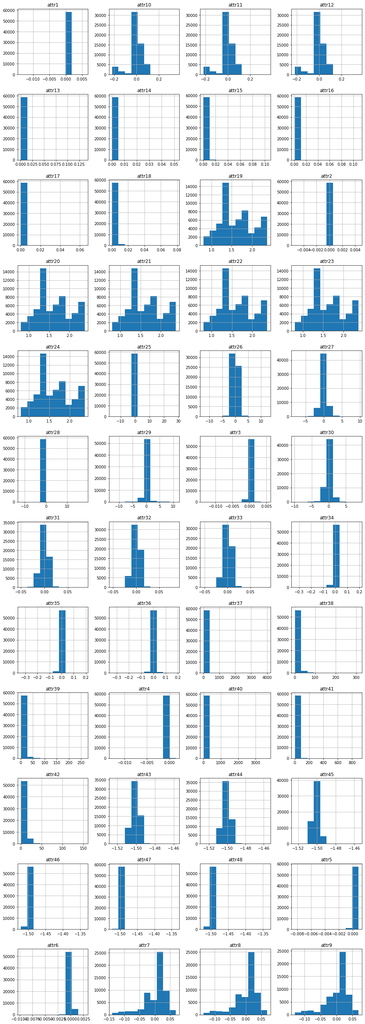

```python
# Histograms for each attribute
X_original.hist(layout=(dispRow,dispCol))
plt.show()
```

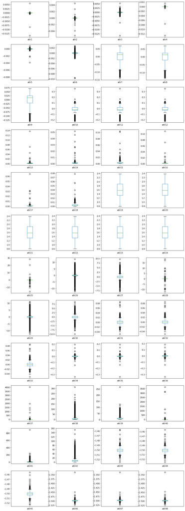

```python
# Box and Whisker plot for each attribute
X_original.plot(kind='box', subplots=True, layout=(dispRow,dispCol))
plt.show()
```

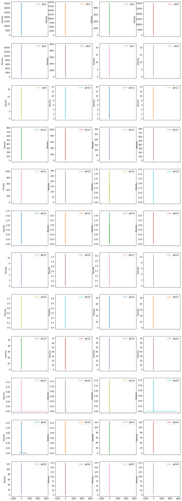

```python
# Density plot for each attribute
X_original.plot(kind='density', subplots=True, layout=(dispRow,dispCol))
plt.show()
```

#### 2.b.ii) Multivariate plots to better understand the relationships between attributes

```python
# Scatterplot matrix
# scatter_matrix(X_original)
# plt.show()
```

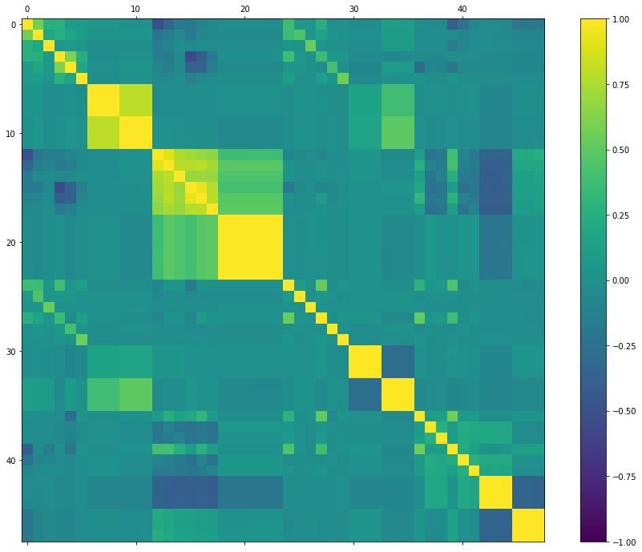

```python
# Correlation matrix
fig = plt.figure(figsize=(16,12))
ax = fig.add_subplot(111)
correlations = X_original.corr(method='pearson')
cax = ax.matshow(correlations, vmin=-1, vmax=1)
fig.colorbar(cax)
plt.show()
```

```python
if (notifyStatus): email_notify("Data Summarization and Visualization completed! "+datetime.now().strftime('%a %B %d, %Y %I:%M:%S %p'))
```

## Section 3 - Prepare Data

Some dataset may require additional preparation activities that will best exposes the structure of the problem and the relationships between the input attributes and the output variable. Some data-prep tasks might include:

- Cleaning data by removing duplicates, marking missing values and even imputing missing values.
- Feature selection where redundant features may be removed.
- Data transforms where attributes are scaled or redistributed in order to best expose the structure of the problem later to learning algorithms.

```python
if (notifyStatus): email_notify("Data Cleaning and Transformation has begun! "+datetime.now().strftime('%a %B %d, %Y %I:%M:%S %p'))
```

### 3.a) Feature Scaling and Data Pre-Processing

```python
# Not applicable for this iteration of the project
```

### 3.b) Splitting Data into Training and Test Sets

```python
# Use 75% of the data to train the models and the remaining for testing/validation

testDataset_size = 0.25
X_train_df, X_test_df, y_train_df, y_test_df = train_test_split(X_original, y_original, test_size=testDataset_size, random_state=seedNum)
print("X_train_df.shape: {} y_train_df.shape: {}".format(X_train_df.shape, y_train_df.shape))
print("X_test_df.shape: {} y_test_df.shape: {}".format(X_test_df.shape, y_test_df.shape))
```

```
X_train_df.shape: (43881, 48) y_train_df.shape: (43881,)
X_test_df.shape: (14628, 48) y_test_df.shape: (14628,)
```

### 3.c) Feature Selection

```python
# Not applicable for this iteration of the project
```

### 3.d) Display the Final Datasets for Model-Building

```python
# Finalize the training and testing datasets for the modeling activities
X_train = X_train_df.values
y_train = y_train_df.values
X_test = X_test_df.values
y_test = y_test_df.values
print("X_train.shape: {} y_train.shape: {}".format(X_train.shape, y_train.shape))
print("X_test.shape: {} y_test.shape: {}".format(X_test.shape, y_test.shape))
```

```
X_train.shape: (43881, 48) y_train.shape: (43881,)
X_test.shape: (14628, 48) y_test.shape: (14628,)
```

```python
if (notifyStatus): email_notify("Data Cleaning and Transformation completed! "+datetime.now().strftime('%a %B %d, %Y %I:%M:%S %p'))
```

## 4. Model and Evaluate Algorithms

After the data-prep, we next work on finding a workable model by evaluating a subset of machine learning algorithms that are good at exploiting the structure of the training. The typical evaluation tasks include:

- Defining test options such as cross validation and the evaluation metric to use.
- Spot checking a suite of linear and nonlinear machine learning algorithms.
- Comparing the estimated accuracy of algorithms.

Linear Algorithm: Linear Discriminant Analysis

Non-Linear Algorithms: Decision Trees (CART) and k-Nearest Neighbors

Ensemble Algorithms: Bagged Decision Trees, Random Forest, Extra Trees, and Gradient Boosting

The random number seed is reset before each run to ensure that the evaluation of each algorithm is performed using the same data splits. It ensures the results are directly comparable.

### 4.a) Set test options and evaluation metric

```python
# Set up Algorithms Spot-Checking Array
startTimeModule = datetime.now()
models = []
models.append(('LDA', LinearDiscriminantAnalysis()))
models.append(('CART', DecisionTreeClassifier(random_state=seedNum)))
models.append(('KNN', KNeighborsClassifier(n_jobs=cpu_num)))
models.append(('BT', BaggingClassifier(random_state=seedNum, n_jobs=cpu_num)))
models.append(('RF', RandomForestClassifier(random_state=seedNum, n_jobs=cpu_num)))
models.append(('ET', ExtraTreesClassifier(random_state=seedNum, n_jobs=cpu_num)))
models.append(('GBM', GradientBoostingClassifier(random_state=seedNum)))
# models.append(('XGB', XGBClassifier(random_state=seedNum, n_jobs=cpu_num)))
results = []
names = []
metrics = []
```

```python
# Generate model in turn
for name, model in models:
	if (notifyStatus): email_notify("Algorithm "+name+" modeling has begun! "+datetime.now().strftime('%a %B %d, %Y %I:%M:%S %p'))
	startTimeModule = datetime.now()
	kfold = KFold(n_splits=num_folds, random_state=seedNum)
	cv_results = cross_val_score(model, X_train, y_train, cv=kfold, scoring=scoring)
	results.append(cv_results)
	names.append(name)
	metrics.append(cv_results.mean())
	msg = "%s: %f (%f)" % (name, cv_results.mean(), cv_results.std())
	print(msg)
	print ('Model training time:',(datetime.now() - startTimeModule))
	if (notifyStatus): email_notify("Algorithm "+name+" modeling completed! "+datetime.now().strftime('%a %B %d, %Y %I:%M:%S %p'))
print ('Average metrics ('+scoring+') from all models:',np.mean(metrics))
print ('Total training time for all models:',(datetime.now() - startTimeModule))
```

```
LDA: 0.847611 (0.004250)
Model training time: 0:00:03.253405
CART: 0.983387 (0.001478)
Model training time: 0:00:34.217594
KNN: 0.113717 (0.004914)
Model training time: 0:00:12.302179
BT: 0.988788 (0.002271)
Model training time: 0:00:45.529448
RF: 0.997493 (0.000828)
Model training time: 0:00:07.932407
ET: 0.999316 (0.000367)
Model training time: 0:00:03.367004
GBM: 0.995442 (0.000789)
Model training time: 1:00:34.949098
Average metrics (accuracy) from all models: 0.8465362869402254
Total training time for all models: 1:00:34.949808
```

### 4.b) Spot-checking baseline algorithms

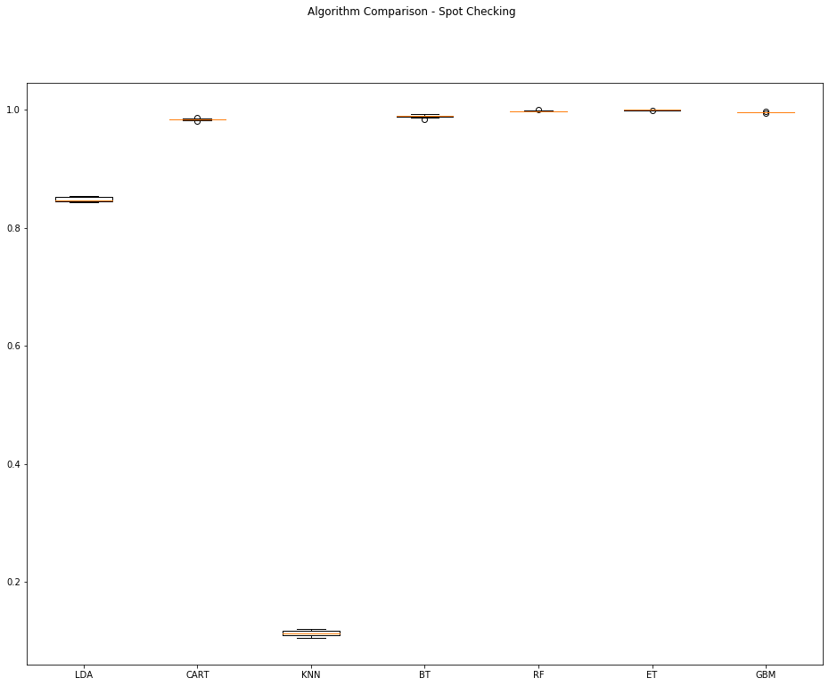

```python
fig = plt.figure(figsize=(16,12))
fig.suptitle('Algorithm Comparison - Spot Checking')
ax = fig.add_subplot(111)
plt.boxplot(results)
ax.set_xticklabels(names)
plt.show()
```

## Section 5 - Improve Accuracy

After we achieve a short list of machine learning algorithms with good level of accuracy, we can leverage ways to improve the accuracy of the models.

### 5.a) Algorithm Tuning

```python
# Set up the comparison array
results = []
names = []
```

```python
# Tuning algorithm #1 - Extra Trees
if (notifyStatus): email_notify("Algorithm #1 tuning has begun! "+datetime.now().strftime('%a %B %d, %Y %I:%M:%S %p'))
startTimeModule = datetime.now()
paramGrid1 = dict(n_estimators=np.array([25, 50, 75, 100, 150]))
model1 = ExtraTreesClassifier(random_state=seedNum, n_jobs=cpu_num)
kfold = KFold(n_splits=num_folds, random_state=seedNum)
grid1 = GridSearchCV(estimator=model1, param_grid=paramGrid1, scoring=scoring, cv=kfold)
grid_result1 = grid1.fit(X_train, y_train)

print("Best: %f using %s" % (grid_result1.best_score_, grid_result1.best_params_))
results.append(grid_result1.cv_results_['mean_test_score'])
names.append('ET')
means = grid_result1.cv_results_['mean_test_score']
stds = grid_result1.cv_results_['std_test_score']
params = grid_result1.cv_results_['params']
for mean, stdev, param in zip(means, stds, params):
    print("%f (%f) with: %r" % (mean, stdev, param))
print ('Model training time:',(datetime.now() - startTimeModule))
if (notifyStatus): email_notify("Algorithm #1 tuning completed! "+datetime.now().strftime('%a %B %d, %Y %I:%M:%S %p'))
```

```
Best: 0.999521 using {'n_estimators': 25}
0.999521 (0.000238) with: {'n_estimators': 25}
0.999521 (0.000123) with: {'n_estimators': 50}
0.999499 (0.000137) with: {'n_estimators': 75}
0.999499 (0.000137) with: {'n_estimators': 100}
0.999476 (0.000146) with: {'n_estimators': 150}
Model training time: 0:01:17.200930
```

```python
# Tuning algorithm #2 - Random Forest
if (notifyStatus): email_notify("Algorithm #2 tuning has begun! "+datetime.now().strftime('%a %B %d, %Y %I:%M:%S %p'))
startTimeModule = datetime.now()
paramGrid2 = dict(n_estimators=np.array([50, 100, 150, 200, 250]))
model2 = RandomForestClassifier(random_state=seedNum, n_jobs=cpu_num)
kfold = KFold(n_splits=num_folds, random_state=seedNum)
grid2 = GridSearchCV(estimator=model2, param_grid=paramGrid2, scoring=scoring, cv=kfold)
grid_result2 = grid2.fit(X_train, y_train)

print("Best: %f using %s" % (grid_result2.best_score_, grid_result2.best_params_))
results.append(grid_result2.cv_results_['mean_test_score'])
names.append('RF')
means = grid_result2.cv_results_['mean_test_score']
stds = grid_result2.cv_results_['std_test_score']
params = grid_result2.cv_results_['params']
for mean, stdev, param in zip(means, stds, params):
    print("%f (%f) with: %r" % (mean, stdev, param))
print ('Model training time:',(datetime.now() - startTimeModule))
if (notifyStatus): email_notify("Algorithm #2 tuning completed! "+datetime.now().strftime('%a %B %d, %Y %I:%M:%S %p'))
```

```
Best: 0.998542 using {'n_estimators': 200}
0.998382 (0.000648) with: {'n_estimators': 50}
0.998450 (0.000627) with: {'n_estimators': 100}
0.998473 (0.000645) with: {'n_estimators': 150}
0.998542 (0.000622) with: {'n_estimators': 200}
0.998496 (0.000569) with: {'n_estimators': 250}
Model training time: 0:06:46.286044
```

### 5.b) Compare Algorithms After Tuning

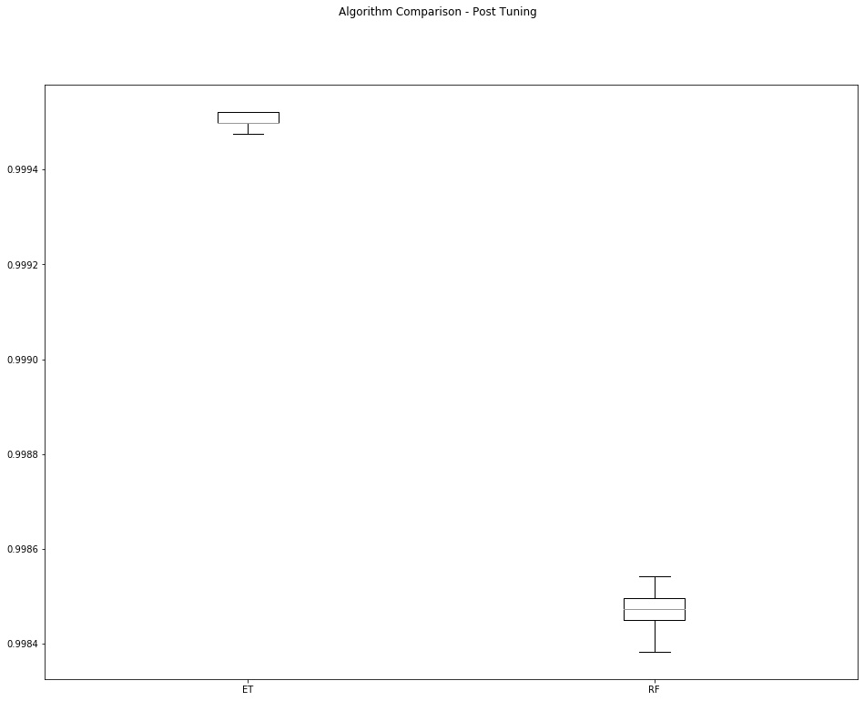

```python
fig = plt.figure(figsize=(16,12))
fig.suptitle('Algorithm Comparison - Post Tuning')
ax = fig.add_subplot(111)
plt.boxplot(results)
ax.set_xticklabels(names)
plt.show()
```

## Section 6 - Finalize Model

Once we have narrow down to a model that we believe can make accurate predictions on unseen data, we are ready to finalize it. Finalizing a model may involve sub-tasks such as:

- Using an optimal model tuned to make predictions on unseen data.
- Creating a standalone model using the tuned parameters
- Saving an optimal model to file for later use.

```python
if (notifyStatus): email_notify("Model Validation and Final Model Creation has begun! "+datetime.now().strftime('%a %B %d, %Y %I:%M:%S %p'))
```

### 6.a) Measure predictions from the test dataset

```python
model = ExtraTreesClassifier(n_estimators=25, random_state=seedNum, n_jobs=cpu_num)
model.fit(X_train, y_train)
predictions = model.predict(X_test)
print('Accuracy Score:', accuracy_score(y_test, predictions))
print(confusion_matrix(y_test, predictions))
print(classification_report(y_test, predictions))
```

```
Accuracy Score: 0.9997265518184304
[[1323    0    0    0    0    0    0    0    0    0    0]
 [   0 1327    1    0    0    0    0    0    1    0    0]
 [   0    0 1344    0    0    0    0    0    0    0    0]
 [   0    0    0 1317    0    0    0    0    0    0    0]
 [   0    0    0    0 1332    0    0    0    0    0    0]
 [   0    1    0    0    0 1346    0    0    0    0    0]
 [   0    0    0    0    0    0 1331    0    0    0    0]
 [   0    0    0    0    0    0    0 1323    0    0    0]
 [   0    0    0    0    0    0    0    0 1302    0    0]
 [   0    1    0    0    0    0    0    0    0 1334    0]
 [   0    0    0    0    0    0    0    0    0    0 1345]]
              precision    recall  f1-score   support

           1       1.00      1.00      1.00      1323
           2       1.00      1.00      1.00      1329
           3       1.00      1.00      1.00      1344
           4       1.00      1.00      1.00      1317
           5       1.00      1.00      1.00      1332
           6       1.00      1.00      1.00      1347
           7       1.00      1.00      1.00      1331
           8       1.00      1.00      1.00      1323
           9       1.00      1.00      1.00      1302
          10       1.00      1.00      1.00      1335
          11       1.00      1.00      1.00      1345

    accuracy                           1.00     14628
   macro avg       1.00      1.00      1.00     14628
weighted avg       1.00      1.00      1.00     14628
```

```python
model = RandomForestClassifier(n_estimators=200, random_state=seedNum, n_jobs=cpu_num)
model.fit(X_train, y_train)
predictions = model.predict(X_test)
print('Accuracy Score:', accuracy_score(y_test, predictions))
print(confusion_matrix(y_test, predictions))
print(classification_report(y_test, predictions))
```

```
Accuracy Score: 0.9987694831829368
[[1323    0    0    0    0    0    0    0    0    0    0]
 [   0 1325    1    0    0    0    0    0    1    2    0]
 [   0    0 1344    0    0    0    0    0    0    0    0]
 [   0    0    0 1317    0    0    0    0    0    0    0]
 [   0    0    2    1 1327    0    0    2    0    0    0]
 [   1    0    0    0    0 1345    0    0    1    0    0]
 [   0    0    0    0    0    0 1331    0    0    0    0]
 [   0    0    0    1    0    0    0 1322    0    0    0]
 [   0    3    0    0    0    0    0    0 1298    1    0]
 [   0    2    0    0    0    0    0    0    0 1333    0]
 [   0    0    0    0    0    0    0    0    0    0 1345]]
              precision    recall  f1-score   support

           1       1.00      1.00      1.00      1323
           2       1.00      1.00      1.00      1329
           3       1.00      1.00      1.00      1344
           4       1.00      1.00      1.00      1317
           5       1.00      1.00      1.00      1332
           6       1.00      1.00      1.00      1347
           7       1.00      1.00      1.00      1331
           8       1.00      1.00      1.00      1323
           9       1.00      1.00      1.00      1302
          10       1.00      1.00      1.00      1335
          11       1.00      1.00      1.00      1345

    accuracy                           1.00     14628
   macro avg       1.00      1.00      1.00     14628
weighted avg       1.00      1.00      1.00     14628
```

### 6.b) Create a standalone model using all available data

```python
startTimeModule = datetime.now()

# Combining the training and testing datasets to form the complete dataset that will be used for training the final model
X_complete = np.vstack((X_train, X_test))
y_complete = np.concatenate((y_train, y_test))
print("X_complete.shape: {} y_complete.shape: {}".format(X_complete.shape, y_complete.shape))

# finalModel = ExtraTreesClassifier(n_estimators=25, random_state=seedNum, n_jobs=cpu_num)
# finalModel.fit(X_complete, y_complete)
# print ('Model training time:',(datetime.now() - startTimeModule))
```

```
X_complete.shape: (58509, 48) y_complete.shape: (58509,)
```

### 6.c) Save the final model for later use

```python
# modelName = 'finalModel_BinaryClass.sav'
# dump(finalModel, modelName)
```

```python
if (notifyStatus): email_notify("Model Validation and Final Model Creation completed! "+datetime.now().strftime('%a %B %d, %Y %I:%M:%S %p'))
```

```python
print ('Total time for the script:',(datetime.now() - startTimeScript))
```

```
Total time for the script: 1:13:11.784396
```